# Session 3 - Topic modelling

Ana Macanovic

2024-11-26

This script evaluates unsupervised machine learning models for topic modelling.

We will survey the following models:

1. LDA - [Latent Dirichlet Allocation](https://www.ibm.com/topics/latent-dirichlet-allocation) - an unsupervised method
2. keyATM - a so-called “semi-supevised” method using keywords in combination with topic modelling, see more [here](https://keyatm.github.io/keyATM/)

Before we start, we define a helping function that will take care of installing and loading the necessary R packages:

```r
## check which packages need to be loaded/installed
# adapted from Jochem Tolsma
fpackage_check <- function(packages) {
  for (package in packages){
    if (!require(package, character.only = TRUE)) {
      install.packages(package, dependencies = TRUE)
      library(package, character.only = TRUE)
    }
  }
}
```

Then, let us load all the necessary R packages:

```r
package_list <- c("tidytext",  # helpful for various text analysis pipelines
                  "dplyr",  # useful for data wrangling in R
                  "readr",  # reading in .csv files
                  "topicmodels", # function for the LDA
                  "keyATM", # function for keyATM
                  "tm", # for document-term matrices
                  "quanteda", # for document-feature matrices
                  "ggplot2" # plotting words and topics
)
# installing the packages
fpackage_check(package_list)
```

## Data loading

Now, load the data. We will be using the “Associated press” dataset from the “topicmodels” R package.

This is a dataset containing 2246 news articles published around 1988 by the Associated Press, an American news agency. Bear in mind that this dataset is already in the DTM (document-term matrix) format we discussed during the first sesssion.

Below, we first load this dataset:

```r
data("AssociatedPress")
```

If we want to inspect it, we can transform it into a regular matrix and check some rows/columns. Below, we see that word “aaron” appears in the first document once; the word “abs” appears in the fifth document twice, etc.

```r
ap_dtm <- as.matrix(AssociatedPress)

ap_dtm[175:180, 1:10]
```

```
##       Terms
## Docs   aaron abandon abandoned abandoning abbott abboud abc abcs abctvs abdomen
##   [1,]     1       0         0          0      0      0   0    0      0       0
##   [2,]     0       0         0          0      0      0   0    0      0       0
##   [3,]     0       0         0          0      0      0   0    0      0       0
##   [4,]     0       0         0          0      0      0   0    0      0       0
##   [5,]     0       0         0          0      0      0   2    1      0       0
##   [6,]     0       0         0          0      0      0   0    0      0       0
```

We can also check the number of rows (texts/documents) and columns (words) in this dataset. We see that the dataset contains 2246 documents, and more than 10 thousand columns - signifying unique words (here called terms).

```r
AssociatedPress
```

```
## <<DocumentTermMatrix (documents: 2246, terms: 10473)>>
## Non-/sparse entries: 302031/23220327
## Sparsity           : 99%
## Maximal term length: 18
## Weighting          : term frequency (tf)
```

```r
ap_dtm_subset <- AssociatedPress[1:1000,]

ap_dtm_subset <- tm::removeSparseTerms(AssociatedPress, .99)
```

```r
ap_dtm_subset
```

```
## <<DocumentTermMatrix (documents: 2246, terms: 3079)>>
## Non-/sparse entries: 234547/6680887
## Sparsity           : 97%
## Maximal term length: 15
## Weighting          : term frequency (tf)
```

“Sparsity reduction” is often used in automatic text analysis under the assumption that infrequent words contribute little important information, but increase the computational cost. Depending on the particular application, however, you might want to retain rare, but important terms in your DTM.

```r
rowTotals <- apply(ap_dtm_subset , 1, sum) #Find the sum of words in each Document
ap_dtm_subset  <- ap_dtm_subset[rowTotals> 0, ]           #remove all docs without words
```

Check how many rows we’ve removed - turns out there was only one problematic text.

```r
ap_dtm_subset
```

```
## <<DocumentTermMatrix (documents: 2245, terms: 3079)>>
## Non-/sparse entries: 234547/6677808
## Sparsity           : 97%
## Maximal term length: 15
## Weighting          : term frequency (tf)
```

## Latent Dirichlet Allocation

To read more about how the LDA workds, you can consult [this](https://cbail.github.io/ids704/topic-modeling/Topic_Modeling.html) excellent guide. There, you can also find more R code examples.

In short, LDA will look at word frequencies (in the DTM) in texts and try to determine which words appear in the same document more than one would expect them to by chance. Based on this, it groups words into “topics” - and also outputs the extent to which each text is made up from each of the topics.

Because LDA only relies on the probability distributions of words already in the data - and does not need any manual input (e.g., category labels, as we have seen in the session on sentiment classification), it is called an “unsupervised” machine learning method. This is unlike random forest algorithms we have surveyed before, which are a “supervised” machine learning algorithm - that is, they need some type of “ground truth” to learn from.

When working with LDA, you have to determine the number of topics that you want the algorithm to identify. This can be done based on experience, a-priori expectations, or by using special tools (like the one [here](https://cran.r-project.org/web/packages/ldatuning/index.html)).

For now, we will seek 10 topics for this example case.

We now fit the LDA model using the “AssociatedPress” DTM object we loaded into memory. We set the “seed” - just to ensure [reproducibility](https://www.statology.org/set-seed-in-r/). We set the parameter k - the number of topics - to 10.

```r
lda_model <- LDA(ap_dtm_subset,
                 k=10,
                 control = list(seed = 123))
```

Now, we can extract the model’s output.

There are two interesting things about LDA output: 1. words constituting different topics; 2. topics constituting different texts;

We will start by inspecting the topics. We first extract the model content using the “tidy” function:

```r
lda_topics <- tidy(lda_model)
```

The resulting dataframe contains words in our dataset, and the beta values for each words’ association with each of the 10 topics. In simple terms, the higher the beta, the more associated this word is with a certain topic as per the LDA model.

```r
lda_topics %>%
  head(5)
```

```
## # A tibble: 5 × 3
##   topic term           beta
##   <int> <chr>         <dbl>
## 1     1 abandoned 0.000111
## 2     2 abandoned 0.0000910
## 3     3 abandoned 0.000164
## 4     4 abandoned 0.000114
## 5     5 abandoned 0.0000540
```

We can now plot the 15 most relevant words for each topic to get a high-level overview of these topics (code courtery of Julia Silge). First, we will select the 15 words with the highest beta score per topic:

```r
topic_words <- lda_topics %>%
  group_by(topic) %>% # grouping by topic
  top_n(15, beta) # selecting 15 words with the highest beta value
```

And now plot them out:

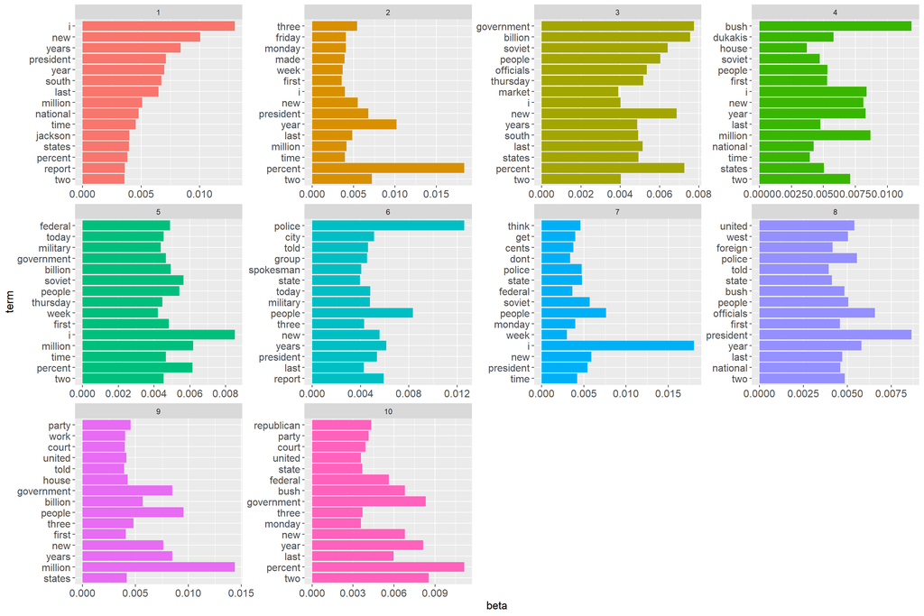

```r
topic_words %>%
   mutate(term = reorder(term, beta)) %>%
  ggplot(aes(term, beta, fill = factor(topic)))+
   geom_col(show.legend = FALSE) +
  facet_wrap(~ topic, scales = "free") +
  coord_flip()+
   theme(plot.title = element_text(size = 12),
        axis.text.y = element_text(size = 12),
        axis.title.y = element_text(size = 13),
        axis.text.x = element_text(size = 12) ,
        axis.title.x = element_text(size = 13),
        legend.title=element_text(size=13),
        legend.text=element_text(size=12))
```

We can now some time to interpret these results a bit.

Another piece of information we can extract from our LDA model is the probability distribution of topics within texts. In simpler terms - how much of this text is made up of which topic?

First, we extract these topic distributions from the model:

```r
lda_topic_distributions <- lda_model@gamma
```

And then we can inspect them for the first five texts, to get a general idea of what is going on. We can see that the topics above are relatively equally distributed across text. Depending on an invidiual use case, one could change certain LDA parameters to accomodate the expectation that texts in a dataset would mostly be made up of a few topics.

```r
round(lda_topic_distributions[1:5, ], 3)
```

```
##       [,1]  [,2]  [,3]  [,4]  [,5]  [,6]  [,7]  [,8]  [,9] [,10]
## [1,] 0.097 0.097 0.097 0.097 0.096 0.107 0.111 0.102 0.097 0.099
## [2,] 0.096 0.097 0.100 0.099 0.101 0.105 0.104 0.102 0.103 0.094
## [3,] 0.100 0.098 0.097 0.103 0.100 0.110 0.103 0.101 0.095 0.094
## [4,] 0.105 0.102 0.099 0.099 0.099 0.099 0.097 0.101 0.099 0.100
## [5,] 0.100 0.102 0.099 0.100 0.098 0.100 0.100 0.100 0.101 0.100
```

## keyATM

We will now explore “keyATM” - a semi-supervised machine learning model. This model is called “semi-supervised” because it combines the approach we’ve seen with LDA (looking at statistical properties of the data themselves) with human guidance we have seen in supervised methods. keyATM allows us to specify a few crucial words we are interested in; it will then use these words as “seeds” around which to build topics. This is particularly useful if you are interested in certain concepts and want the model to focus on them, rather than on all relationships in the dataset.

You can find more details on this method [here](https://keyatm.github.io/keyATM/).

First, we will convert our DTM into a slightly different format called the Document-feature matrix (DFM). This is just a practical matter, as the R implementation we are working with prefers the DTM format of the “quanteda” R package (the DFM) rather the DTM format of the “tm” R package (which is preferred by the “topicmodels” package we used for LDA above). You will run into many such inconsistencies when working with text mining software solutions in R. Oftentimes, they reflect the personal preferences of the authors who have written the software you are using. If you run into an issue, a simple Google search will usually help resolve it quickly.

Converting the DTM into a DFM:

```r
ap_dfm_subset <- as.dfm(ap_dtm_subset)
```

If we check this object, we can see it is identical in its content to the DTM. Here is the DTM:

```r
as.matrix(ap_dtm_subset)[175:180, 1:10]
```

```
##       Terms
## Docs   abandoned abc ability able aboard abroad absolutely abuse academy accept
##   [1,]         0   0       0    0      0      0          0     0       0      0
##   [2,]         0   0       0    0      0      0          0     0       0      0
##   [3,]         0   0       0    0      0      0          0     0       0      0
##   [4,]         0   0       0    0      0      0          0     0       0      0
##   [5,]         0   2       0    0      0      0          0     0       0      0
##   [6,]         0   0       0    1      0      0          0     0       0      0
```

And here is the DFM:

```r
ap_dfm_subset[175:180, 1:10]
```

```
## Document-feature matrix of: 6 documents, 10 features (96.67% sparse) and 0 docvars.
##          features
## docs      abandoned abc ability able aboard abroad absolutely abuse academy
##   text175         0   0       0    0      0      0          0     0       0
##   text176         0   0       0    0      0      0          0     0       0
##   text177         0   0       0    0      0      0          0     0       0
##   text178         0   0       0    0      0      0          0     0       0
##   text179         0   2       0    0      0      0          0     0       0
##   text180         0   0       0    1      0      0          0     0       0
##          features
## docs      accept
##   text175      0
##   text176      0
##   text177      0
##   text178      0
##   text179      0
##   text180      0
```

Now, we use a special function to “process” the DFM into the data format that keyATM needs:

```r
keyATM_docs <- keyATM_read(texts = ap_dfm_subset)
```

Now, let us say we want to single out one topic that relates to police, and let the model define the remaining 9 topics as it wishes. We can choose a few keywords to work with:

```r
police_keywords <- c("police", "officer", "patrol")
```

And then fit the model so that this one topic is centered around the keywords above, and the remaining 9 (10 - 1) are determined by the model:

```r
keyatm_model <- keyATM(
  docs = keyATM_docs, # plug in our data
  no_keyword_topics = 9, #  specify the number of topics without keywords
  keywords = list(police_keywords), # specify the keywords
  options = list(seed = 123), # and, once again, set the seed
  model = "base" # use the base model, sufficient for now
)
```

Now we can use a convenient function of the keyATM package to inspect the top words for each topic. The first topic is centered around police - just as we requested; the rest are rather coherent and refer to: 1988 US elections (Bush/Dukakis), the Gulf war, court cases, etc. As keyATM uses a different algorithm with diferent parameters compared to LDA, you can see that the results are also rather different than those we get from LDA.

```r
top_words(keyatm_model, 15)
```

```
##             1      Other_1  Other_2       Other_3    Other_4 Other_5   Other_6
## 1  police [✓]         bush     iraq         court        new percent    soviet
## 2      people      dukakis military          case       york  market    united
## 3         two     campaign   united      attorney       city  prices     south
## 4   officials       senate   kuwait         judge california   stock gorbachev
## 5       three    president    iraqi       federal   american million      west
## 6      killed        house   states         trial      first    year    states
## 7       miles   republican american          drug       last  dollar      east
## 8     yearold         bill   troops       charges       year     new     union
## 9        city   democratic    saudi        prison   national    rose     talks
## 10       four          sen     gulf           law       john trading       aid
## 11        man       reagan     iran         state      water   cents officials
## 12       five      jackson      oil       justice        san  higher    german
## 13       died presidential      war      district       show   rates    israel
## 14        day         vote    force investigation        los   price   foreign
```

[output cut: 17 more lines]

And similar to what we have done before, we can now inspect the composition of documents with relation to different topics.

Extract the topic distributions (called “theta” in this family of models)

```r
keyatm_topic_distributions <- keyatm_model$theta  # Document-topic distribution
```

And inspect them. You will see that the results are quite different - the first text seems to be very related to the “police” topic, while other topics identified by keyATM appear less relevant for this first text:

```r
round(keyatm_topic_distributions[1:5, ], 3)
```

```
##          1 Other_1 Other_2 Other_3 Other_4 Other_5 Other_6 Other_7 Other_8
## [1,] 0.701   0.000   0.000   0.051   0.046   0.000   0.000   0.200   0.001
## [2,] 0.143   0.000   0.090   0.048   0.001   0.000   0.133   0.239   0.147
## [3,] 0.555   0.000   0.000   0.016   0.135   0.000   0.000   0.292   0.001
## [4,] 0.106   0.072   0.091   0.000   0.255   0.092   0.066   0.153   0.001
## [5,] 0.276   0.001   0.000   0.001   0.002   0.001   0.001   0.605   0.002
##      Other_9
## [1,]   0.001
## [2,]   0.200
## [3,]   0.001
## [4,]   0.164
## [5,]   0.112
```